# R Notebook

# Preloads Energy Consumption

# Housekeeping

First we set the working directory

```r
dir = "/home/omar/thesis-replication-package/preloads/data_analysis"
```

```r
setwd(dir)
```

Next we import the libraries we need.

```r
library(ggplot2)
library(e1071)
library(dplyr)
library(effsize)
# Import functions we created ourselves.
source("util.r")
```

# Getting the data

We load the data and then reshape it a little bit to make it easier to work with.

```r
monsoon_raw_data <- read.csv("../raw_data/Aggregated_Results_Monsoon.csv")
plt_raw_data <- read.csv("../raw_data/http_post_request_payloads.txt")

combined_data <- combine_and_reshape_dataframes(monsoon_raw_data, plt_raw_data, "noremovepreload")
intact = combined_data[1:200,]
removed = combined_data[201:400,]
print(combined_data)
```

|  | subject | treatment | run | energy_joules | plt |
| --- | --- | --- | --- | --- | --- |
| 1 | affirm-com | intact | 1 | 32.876551 | 14052 |
| 81 | affirm-com | intact | 2 | 30.363543 | 12295 |
| 161 | affirm-com | intact | 3 | 35.345285 | 15147 |
| 241 | affirm-com | intact | 4 | 34.848865 | 12823 |
| 321 | affirm-com | intact | 5 | 35.033510 | 14853 |
| 3 | africafreak-com | intact | 1 | 15.657237 | 6906 |
| 83 | africafreak-com | intact | 2 | 14.172589 | 6245 |
| 163 | africafreak-com | intact | 3 | 14.067621 | 5837 |
| 243 | africafreak-com | intact | 4 | 15.512016 | 5892 |
| 323 | africafreak-com | intact | 5 | 14.389691 | 5993 |

[output cut: 390 more lines]

```r
print(intact)
```

|  | subject | treatment | run | energy_joules | plt |
| --- | --- | --- | --- | --- | --- |
| 1 | affirm-com | intact | 1 | 32.876551 | 14052 |
| 81 | affirm-com | intact | 2 | 30.363543 | 12295 |
| 161 | affirm-com | intact | 3 | 35.345285 | 15147 |
| 241 | affirm-com | intact | 4 | 34.848865 | 12823 |
| 321 | affirm-com | intact | 5 | 35.033510 | 14853 |
| 3 | africafreak-com | intact | 1 | 15.657237 | 6906 |
| 83 | africafreak-com | intact | 2 | 14.172589 | 6245 |
| 163 | africafreak-com | intact | 3 | 14.067621 | 5837 |
| 243 | africafreak-com | intact | 4 | 15.512016 | 5892 |
| 323 | africafreak-com | intact | 5 | 14.389691 | 5993 |

[output cut: 190 more lines]

```r
print(removed)
```

|  | subject | treatment | run | energy_joules | plt |
| --- | --- | --- | --- | --- | --- |
| 2 | affirm-com | removed | 1 | 32.895518 | 13040 |
| 82 | affirm-com | removed | 2 | 28.581027 | 11855 |
| 162 | affirm-com | removed | 3 | 30.544055 | 12516 |
| 242 | affirm-com | removed | 4 | 36.744965 | 15092 |
| 322 | affirm-com | removed | 5 | 30.834266 | 12050 |
| 4 | africafreak-com | removed | 1 | 14.011721 | 6201 |
| 84 | africafreak-com | removed | 2 | 14.472573 | 5810 |
| 164 | africafreak-com | removed | 3 | 15.599276 | 6472 |
| 244 | africafreak-com | removed | 4 | 13.179360 | 7420 |
| 324 | africafreak-com | removed | 5 | 15.918159 | 7483 |

[output cut: 190 more lines]

# Data Exploration

First lets get some summaries of the data..

```r
print("All")
```

```
[1] "All"
```

```r
summary(combined_data$energy_joules)
```

```
   Min. 1st Qu.  Median    Mean 3rd Qu.    Max.
  9.477  16.205  20.688  26.499  27.913 109.622
```

```r
sd(combined_data$energy_joules)
```

```
[1] 18.75762
```

```r
print("Intact")
```

```
[1] "Intact"
```

```r
summary(intact$energy_joules)
```

```
   Min. 1st Qu.  Median    Mean 3rd Qu.    Max.
  9.484  16.209  20.770  26.487  27.709 108.718
```

```r
sd(intact$energy_joules)
```

```
[1] 18.72514
```

```r
print("Removed")
```

```
[1] "Removed"
```

```r
summary(removed$energy_joules)
```

```
   Min. 1st Qu.  Median    Mean 3rd Qu.    Max.
  9.477  16.205  20.546  26.511  28.594 109.622
```

```r
sd(removed$energy_joules)
```

```
[1] 18.83703
```

Then we make a boxplot of the data.

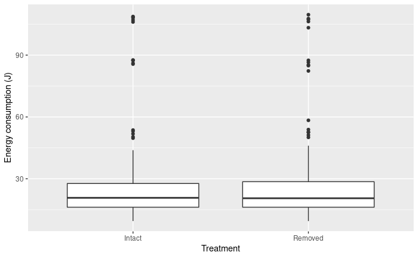

```r
ggplot(combined_data, aes(x=treatment, y=energy_joules)) +
  geom_boxplot() + labs(

              x = "Treatment", y = "Energy consumption (J)") + scale_x_discrete(labels=c("Intact", "Removed"))
ggsave("/home/omar/thesis-replication-package/preloads/data_analysis/plots/box_plot_preloads_energy_consumption.pdf")
```

We can see that the data lies very close together.

```r
outliers <- boxplot.stats(combined_data$energy_joules)$out
out_ind <- which(combined_data$energy_joules %in% c(outliers))
outliers <- combined_data[out_ind,]
print(outliers)
```

|  | subject | treatment | run | energy_joules | plt |
| --- | --- | --- | --- | --- | --- |
| 23 | fastcodesign-com | intact | 1 | 87.55365 | 46815 |
| 103 | fastcodesign-com | intact | 2 | 85.66310 | 46441 |
| 183 | fastcodesign-com | intact | 3 | 86.05196 | 47819 |
| 263 | fastcodesign-com | intact | 4 | 87.59769 | 45018 |
| 343 | fastcodesign-com | intact | 5 | 87.37787 | 46269 |
| 49 | nbc-com | intact | 1 | 50.34006 | 18421 |
| 129 | nbc-com | intact | 2 | 53.63559 | 20938 |
| 209 | nbc-com | intact | 3 | 53.09221 | 20378 |
| 289 | nbc-com | intact | 4 | 51.81082 | 21860 |
| 369 | nbc-com | intact | 5 | 49.72597 | 20227 |

[output cut: 23 more lines]

```r
outliers %>% group_by(subject, treatment) %>% summarise(Count=n())
```

| subject | treatment | Count |
| --- | --- | --- |
| agriwebb-com | removed | 1 |
| fastcodesign-com | intact | 5 |
| fastcodesign-com | removed | 5 |
| ict-moscow | removed | 1 |
| nbc-com | intact | 5 |
| nbc-com | removed | 5 |
| newsbreak-com | removed | 1 |
| scmp-com | intact | 5 |
| scmp-com | removed | 5 |

We see that most of the outliers are all for the same mobile web apps (30/33 outliers) so we decide to not remove them. This is also to be expected as each mobile web app differs from the others in terms of size, logic etc.

# Testing for normality

The paired t-test assumes that the differences between pairs are normally distributed. Lets investigate..

```r
differences <- NULL
differences$subject <- intact$subject
differences$diff <-  removed$energy_joules - intact$energy_joules
differences <- data.frame(differences$subject, differences$diff)
differences <- differences %>%
  rename(
   subject = "differences.subject",
    diff = differences.diff
    )
print(differences)
```

| subject | diff |
| --- | --- |
| affirm-com | 0.01896690 |
| affirm-com | -1.78251593 |
| affirm-com | -4.80122988 |
| affirm-com | 1.89609962 |
| affirm-com | -4.19924431 |
| africafreak-com | -1.64551546 |
| africafreak-com | 0.29998421 |
| africafreak-com | 1.53165502 |
| africafreak-com | -2.33265536 |
| africafreak-com | 1.52846861 |

[output cut: 190 more lines]

```r
summary(differences$diff)
```

```
     Min.   1st Qu.    Median      Mean   3rd Qu.      Max.
-17.96940  -1.95493  -0.29804   0.02456   1.33840  27.98468
```

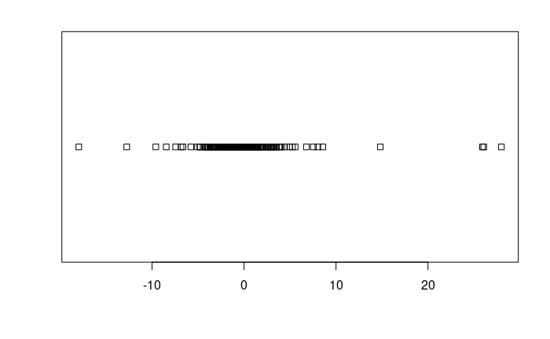

```r
stripchart(differences$diff)
```

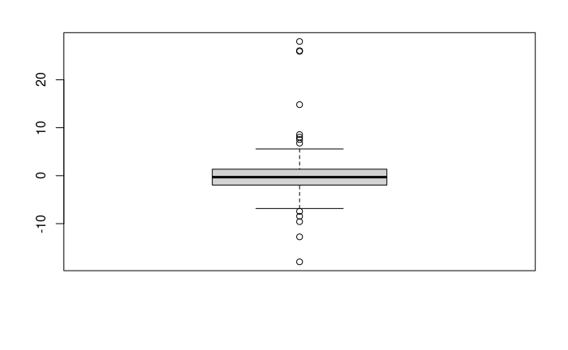

```r
boxplot(differences$diff)
```

We can see that both the median and the mean lie pretty close together. Although we have a slight skew (positively) to the right (mean is larger than median). The average and mean both circle around 0, so no big differences.

Might be interesting to look at the outliers. As we can see the majority of these outliers are,all from a positive difference between pairs so the energy consumption of MWA was higher when the preloads were removed versus when preloads were left intact.

```r
outliers <- boxplot.stats(differences$diff)$out
out_ind <- which(differences$diff %in% c(outliers))
differences[out_ind,]
```

|  | subject | diff |
| --- | --- | --- |
| 11 | agriwebb-com | 7.543224 |
| 43 | cbc-ca | -17.969403 |
| 44 | cbc-ca | 14.818819 |
| 50 | coindesk-com | 8.569172 |
| 82 | ict-moscow | 25.925384 |
| 88 | infobunny-com | -12.752742 |
| 89 | infobunny-com | -9.592762 |
| 103 | jisr-net | -8.458066 |
| 121 | nbc-com | 8.023078 |
| 127 | newsbreak-com | 27.984683 |

[output cut: 3 more lines]

Lets check whether the data is normally distributed. The QQ-plot indicates that the data is not normally distributed. To confirm we apply he Shapiro-Wilk test which returns a p-value of 2.2e-16 meaning that the hypothesis that the data comes from a normal distribution is rejected.

```r
pdf(file="/home/omar/thesis-replication-package/preloads/data_analysis/plots/qqplot_preloads_energy.pdf")
differences <- removed$energy_joules - intact$energy_joules
qqnorm(differences, main="", xlab = "Normal theoretical quantile", ylab="Energy consumption differences sample quantile (J)")
qqline(differences)
dev.off()
```

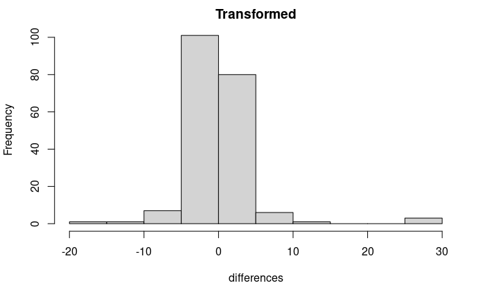

```
[1] "Transformed:  none"

    Shapiro-Wilk normality test

data:  differences
W = 0.73077, p-value < 2.2e-16

[1] "Skewness after transformation 2.53511309731514"
```

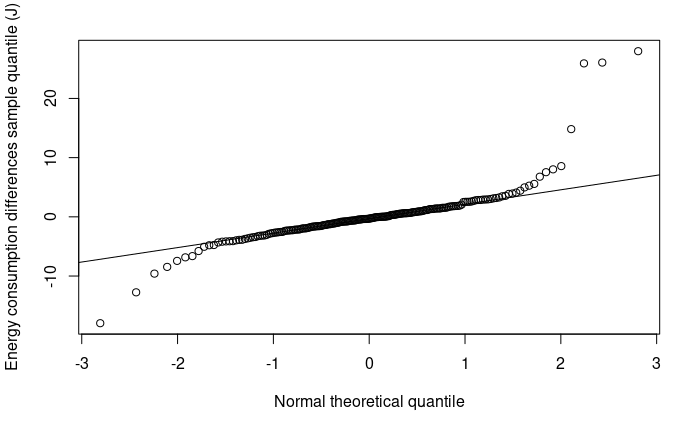

```r
transform_and_test(removed$energy_joules, intact$energy_joules)
```

Since the differences are not normally distributed we apply several transformations to see if we can approach a normal distribution.

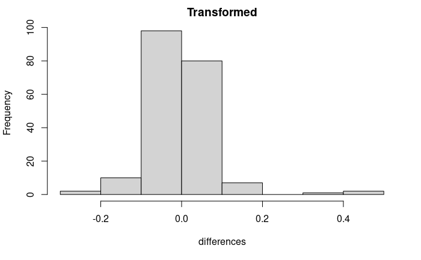

```
[1] "Transformed:  log"

    Shapiro-Wilk normality test

data:  differences
W = 0.85431, p-value = 6.998e-13

[1] "Skewness after transformation 1.51235306123604"
```

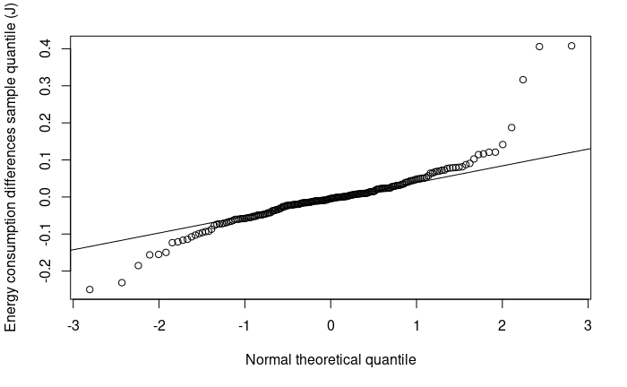

```r
transform_and_test(removed$energy_joules, intact$energy_joules, "log")
```

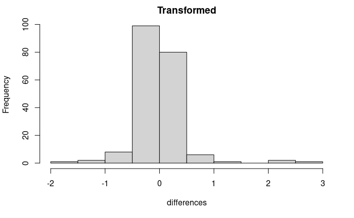

```
[1] "Transformed:  sqrt"

    Shapiro-Wilk normality test

data:  differences
W = 0.79162, p-value = 1.312e-15

[1] "Skewness after transformation 2.06523993103467"
```

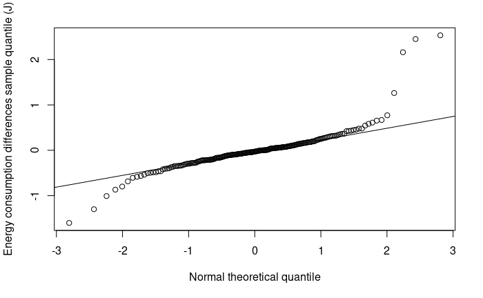

```r
transform_and_test(removed$energy_joules, intact$energy_joules, "sqrt")
```

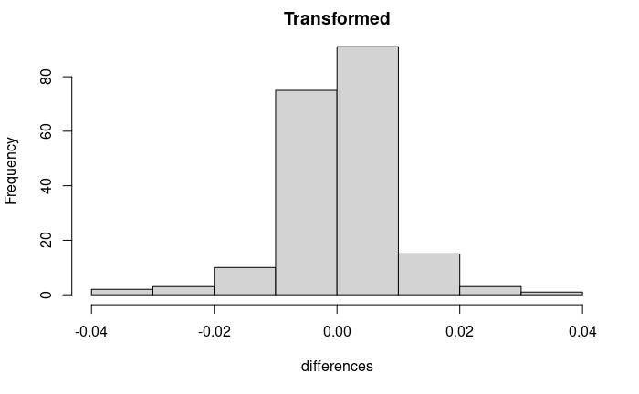

```
[1] "Transformed:  recip"

    Shapiro-Wilk normality test

data:  differences
W = 0.92629, p-value = 1.73e-08

[1] "Skewness after transformation -0.404898568057402"
```

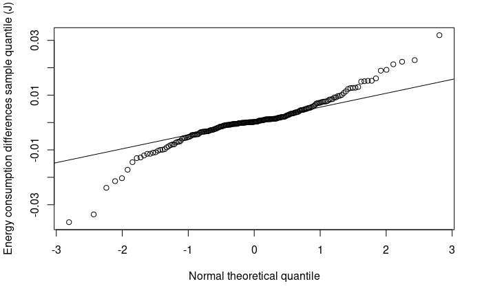

```r
transform_and_test(removed$energy_joules, intact$energy_joules, "recip")
```

We can see that for all three transformations the data is not normally distributed.

# Hypothesis Testing

Since the data is not normally distributed we will use the Wilcoxon signed rank test:

```r
wilcox.test(removed$energy_joules, intact$energy_joules, paired=TRUE)
```

```
    Wilcoxon signed rank test with continuity correction

data:  removed$energy_joules and intact$energy_joules
V = 8893, p-value = 0.1582
alternative hypothesis: true location shift is not equal to 0
```

As we can see this tests gives a p-value of 0.1582 which is above our 0.05 treshold and thus we cannot reject the null hypothesis. So we are not able to claim that there is a significant difference in energy consumption between MWP that use resource preloading or not.

# Effect Size Estimation

```r
cliffs_delta_energy <- cliff.delta(removed$energy_joules, intact$energy_joules)
print(cliffs_delta_energy)
```

```
Cliff's Delta

delta estimate: -0.0177 (negligible)
95 percent confidence interval:
      lower       upper
-0.13050246  0.09555486
```

As expected the value of the Cliff’s delta measure is negligible.